# Session 5: Self-Supervised Learning

Alexandra Strassmann, Samuel Pawel

29. April 2020

## Plan

- **Supervised learning**
  1. *Benchmark*: Fit a neural network to classify images on a large data set with 60000 labelled images as a benchmark
  2. *Benchmark with few labels*: Mimic situation where only very few labels (150 images) are available and fit same model again
- **Self-supervised learning**
  1. *Pretext task*: Perform rotation task on full, unlabelled data set (60000 images). Use random rotation of image as pseudo-label.
  2. *Downstream task with few labels*: Transfer weights from rotation task and try classification again with small data set (150 images)

## Libraries and data

```r
## Libraries
## ------------------------------------------------------------------
library(keras)
library(OpenImageR) # for rotation of images with rotateImage()
set.seed(42)

## Data
## ------------------------------------------------------------------
## loading data
mnist <- dataset_mnist()
str(mnist)
```

```
## List of 2
##  $ train:List of 2
##   ..$ x: int [1:60000, 1:28, 1:28] 0 0 0 0 0 0 0 0 0 0 ...
##   ..$ y: int [1:60000(1d)] 5 0 4 1 9 2 1 3 1 4 ...
##  $ test :List of 2
##   ..$ x: int [1:10000, 1:28, 1:28] 0 0 0 0 0 0 0 0 0 0 ...
##   ..$ y: int [1:10000(1d)] 7 2 1 0 4 1 4 9 5 9 ...
```

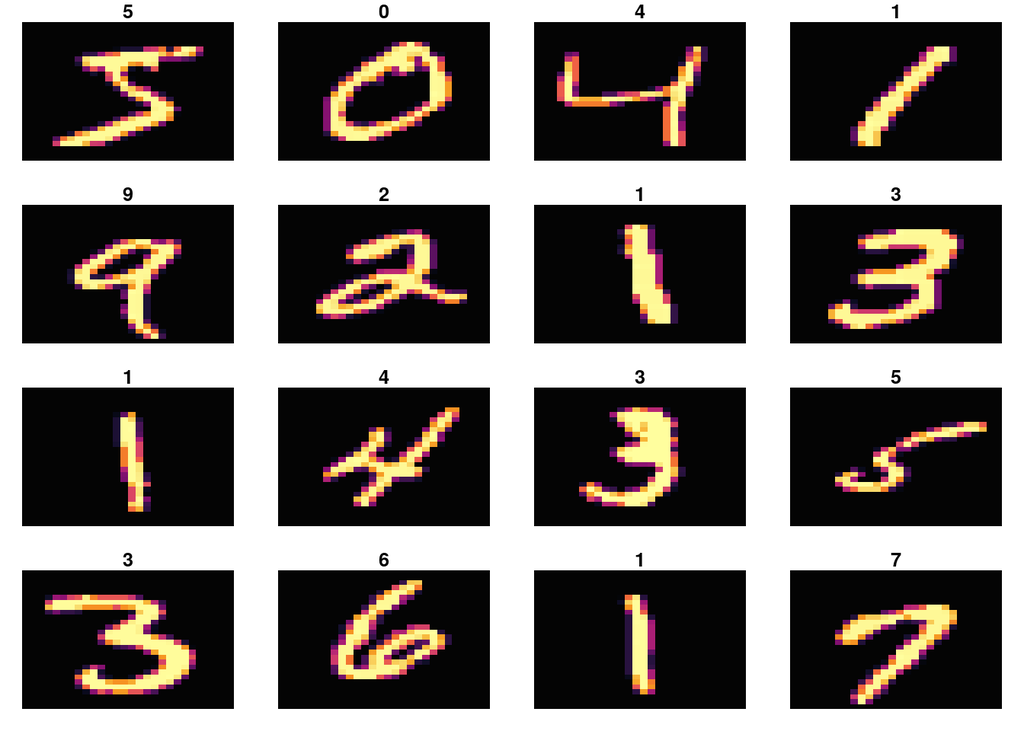

```r
ntrain <- length(mnist$train$y)
ntest <- length(mnist$test$y)

## normalize and reshape images
mnist$train$x <- mnist$train$x / 255
mnist$train$x <- array(mnist$train$x, dim = c(ntrain, 28, 28, 1))
mnist$test$x <- mnist$test$x / 255
mnist$test$x <- array(mnist$test$x, dim = c(ntest, 28, 28, 1))

## one-hot encode labels
mnist$train$yBin <- to_categorical(mnist$train$y, 10)
mnist$test$yBin <- to_categorical(mnist$test$y, 10)

## some plots of the data
par(mfrow = c(4, 4), mai = rep(0.15, 4))
for (i in seq(1, 16)) {
  image(t(apply(mnist$train$x[i,,,1], 2, rev)),
        col = hcl.colors(256, palette = "inferno"),
        axes = FALSE, main = mnist$train$y[i])
}
```

## Fitting a convolutional neural network model (CNN) to all training data

```r
## CNN model
## ------------------------------------------------------------------
## adapted from:
## https://blog.tensorflow.org/2018/04/fashion-mnist-with-tfkeras.html
model <- keras_model_sequential(name = "MNIST-CNN") %>%
  layer_conv_2d(filters = 64, kernel_size = 2, padding = "same",
                activation = "relu", input_shape = c(28, 28, 1)) %>%
  layer_max_pooling_2d(pool_size = 2) %>%
  layer_dropout(rate = 0.3) %>%
  layer_conv_2d(filters = 32, kernel_size = 2, padding = "same",
                activation = "relu") %>%
  layer_max_pooling_2d(pool_size = 2) %>%
  layer_dropout(rate = 0.3) %>%
  layer_flatten() %>%
  layer_dense(units = 256, activation = "relu") %>%
  layer_dropout(rate = 0.5) %>%
  layer_dense(units = 10, activation = "softmax")
summary(model)
```

```
## Model: "MNIST-CNN"
## ________________________________________________________________________________
## Layer (type)                        Output Shape                    Param #
## ================================================================================
## conv2d (Conv2D)                     (None, 28, 28, 64)              320
## ________________________________________________________________________________
## max_pooling2d (MaxPooling2D)        (None, 14, 14, 64)              0
## ________________________________________________________________________________
## dropout (Dropout)                   (None, 14, 14, 64)              0
## ________________________________________________________________________________
## conv2d_1 (Conv2D)                   (None, 14, 14, 32)              8224
## ________________________________________________________________________________
## max_pooling2d_1 (MaxPooling2D)      (None, 7, 7, 32)                0
## ________________________________________________________________________________
## dropout_1 (Dropout)                 (None, 7, 7, 32)                0
## ________________________________________________________________________________
## flatten (Flatten)                   (None, 1568)                    0
## ________________________________________________________________________________
## dense (Dense)                       (None, 256)                     401664
## ________________________________________________________________________________
## dropout_2 (Dropout)                 (None, 256)                     0
## ________________________________________________________________________________
## dense_1 (Dense)                     (None, 10)                      2570
## ================================================================================
## Total params: 412,778
## Trainable params: 412,778
## Non-trainable params: 0
## ________________________________________________________________________________
```

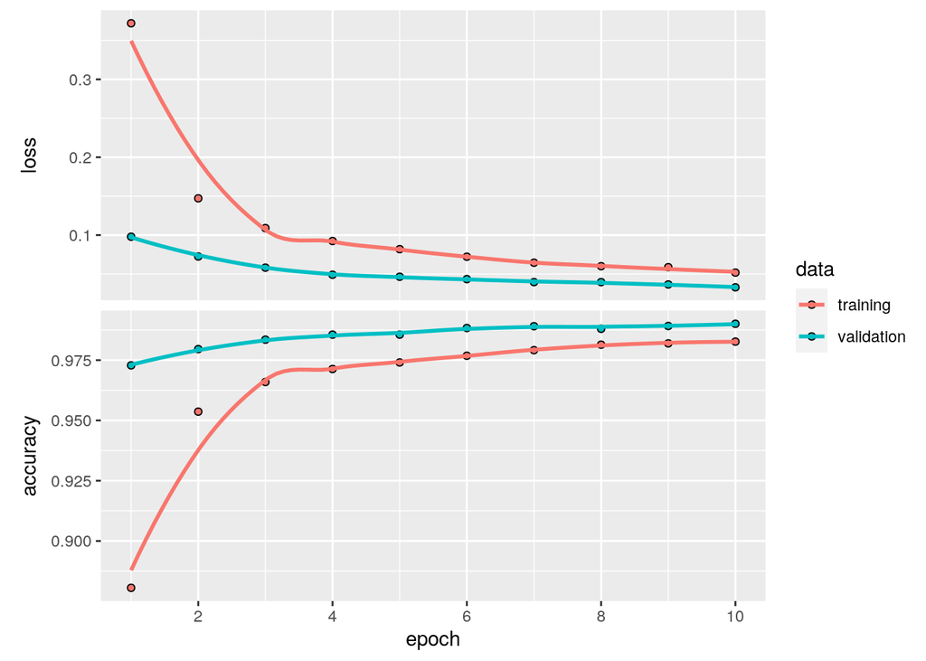

```r
## compile model
model %>%
  compile(loss = "categorical_crossentropy",
          optimizer = "adam",
          metrics = c("accuracy"))

## fit model
history <- model %>%
  fit(x = mnist$train$x,
      y = mnist$train$yBin,
      batch_size = 64,
      epochs = 10,
      validation_split = 0.2)

## plot change of loss/accuracy over course of optimization
plot(history)
```

```r
## evaluate on test data
model %>%
  evaluate(x = mnist$test$x,
           y = mnist$test$yBin,
           verbose = 0)
```

```
## $loss
## [1] 0.02752205
##
## $accuracy
## [1] 0.9915
```

## Fitting same model on only small part of training data

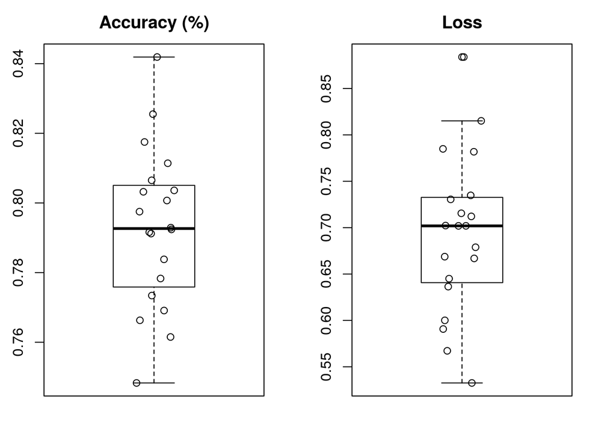

```r
## only taking the first 0.25% training samples to fit model
smallData <- function(perc = 0.0025) {
  smallerN <- 0.0025*ntrain
  ind <- sample(x = seq(1, ntrain), size = smallerN, replace = FALSE)
  x <- array(mnist$train$x[ind,,,], dim = c(smallerN, 28, 28, 1))
  yBin <- mnist$train$yBin[ind,]
  return(list(x = x, yBin = yBin))
}

## formulating same model
modelSmall <- keras_model_sequential(name = "MNIST-CNN-Small") %>%
  layer_conv_2d(filters = 64, kernel_size = 2, padding = "same",
                activation = "relu", input_shape = c(28, 28, 1)) %>%
  layer_max_pooling_2d(pool_size = 2) %>%
  layer_dropout(rate = 0.3) %>%
  layer_conv_2d(filters = 32, kernel_size = 2, padding = "same",
                activation = "relu") %>%
  layer_max_pooling_2d(pool_size = 2) %>%
  layer_dropout(rate = 0.3) %>%
  layer_flatten() %>%
  layer_dense(units = 256, activation = "relu") %>%
  layer_dropout(rate = 0.5) %>%
  layer_dense(units = 10, activation = "softmax")

## compile model
modelSmall %>%
  compile(loss = "categorical_crossentropy",
          optimizer = "adam",
          metrics = c("accuracy"))


## fit model M times with different small data sets and get test error
M <- 20
weightsModelSmall <- get_weights(modelSmall)

testerrSuper <- t(replicate(n = M, expr = {
  ## overwrite weights with initialization weights
  modelSmall %>%
    set_weights(weights = weightsModelSmall)

  ## fit to a small data set
  sdat <- smallData(perc = 0.0025)
  modelSmall %>%
  fit(x = sdat$x,
      y = sdat$yBin,
      batch_size = 1,
      epochs = 10,
      validation_split = 0.2,
      verbose = FALSE)

  ## get test error
  testErr <- modelSmall %>%
  evaluate(x = mnist$test$x,
           y = mnist$test$yBin,
           verbose = 0)
  return(c(loss = testErr$loss, accuracy = testErr$accuracy))
}, simplify = TRUE))
par(mfrow = c(1, 2), mai = rep(0.5, 4))
boxplot(testerrSuper[,2], main = "Accuracy (%)")
stripchart(testerrSuper[,2], add = TRUE, vertical = TRUE, jitter = 0.1,
           pch = 1, method = "jitter")
boxplot(testerrSuper[,1], main = "Loss")
stripchart(testerrSuper[,1], add = TRUE, vertical = TRUE, jitter = 0.1,
           pch = 1, method = "jitter")
```

## Self-Supervised Learning: Pretext Task

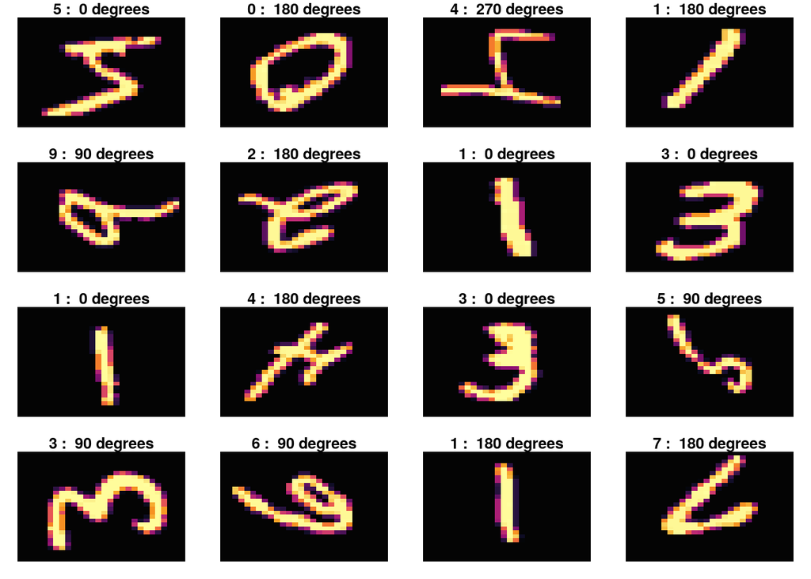

```r
## Pretext task
## ----------------------------------------------------------------------------
## Pseudolabel p: random rotation of image
## 0: 0°, 1: 90°, 2: 180°, 3: 270°
mnist$train$p <- sample(x = c(0, 1, 2, 3), size = ntrain, replace = TRUE)
mnist$test$p <- sample(x = c(0, 1, 2, 3), size = ntest, replace = TRUE)
mnist$train$pBin <- to_categorical(mnist$train$p)
mnist$test$pBin <- to_categorical(mnist$test$p)

## rotating image with OpenImageR::rotateImage()
mnist$train$xRot <- array(dim = c(ntrain, 28, 28, 1))
for (i in seq(1, ntrain)) {
  angle <- mnist$train$p[i]*90
  mnist$train$xRot[i,,,] <- rotateImage(image = mnist$train$x[i,,,],
                                        angle = angle)
}
mnist$test$xRot <- array(dim = c(ntest, 28, 28, 1))
for (i in seq(1, ntest)) {
  angle <- mnist$test$p[i]*90
  mnist$test$xRot[i,,,] <- rotateImage(image = mnist$test$x[i,,,],
                                        angle = angle)
}

## some plots of the rotated data with pseudolabels
par(mfrow = c(4, 4), mai = rep(0.15, 4))
for (i in seq(1, 16)) {
  image(t(apply(mnist$train$xRot[i,,,1], 2, rev)),
        col = hcl.colors(256, palette = "inferno"),
        axes = FALSE,
        main = paste(mnist$train$y[i], ": ", mnist$train$p[i]*90, "degrees"))
}
```

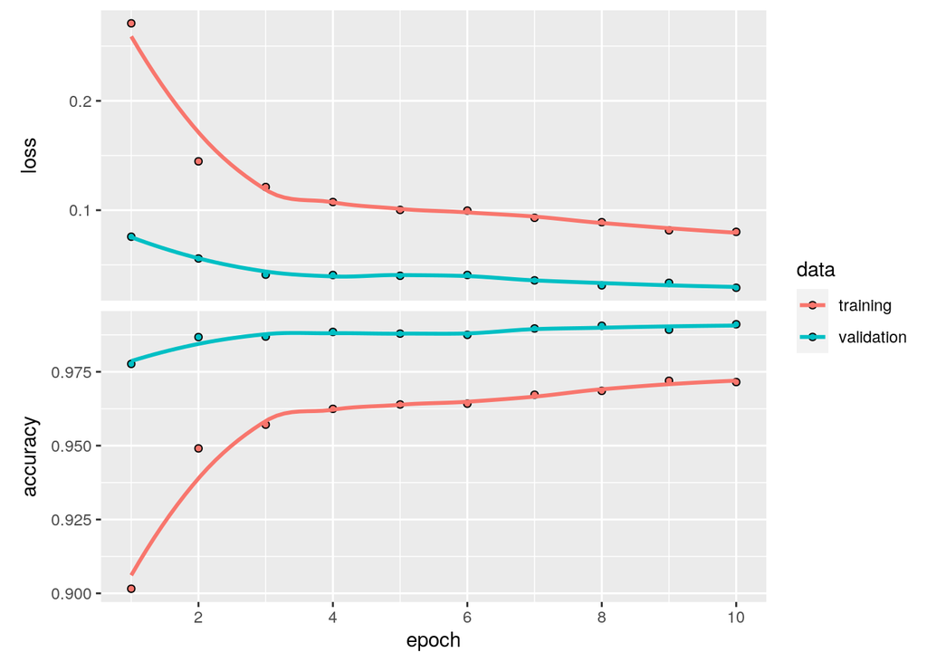

```r
## CNN model for rotation classification
modelRot <- keras_model_sequential(name = "MNIST-CNN-Rotation") %>%
  layer_conv_2d(filters = 64, kernel_size = 2, padding = "same",
                activation = "relu", input_shape = c(28, 28, 1)) %>%
  layer_max_pooling_2d(pool_size = 2) %>%
  layer_dropout(rate = 0.3) %>%
  layer_conv_2d(filters = 32, kernel_size = 2, padding = "same",
                activation = "relu") %>%
  layer_max_pooling_2d(pool_size = 2) %>%
  layer_dropout(rate = 0.3) %>%
  layer_flatten() %>%
  layer_dense(units = 256, activation = "relu") %>%
  layer_dropout(rate = 0.5) %>%
  layer_dense(units = 4, activation = "softmax")

## compile model
modelRot %>%
  compile(loss = "categorical_crossentropy",
          optimizer = "adam",
          metrics = c("accuracy"))

## fit model
historyRot <- modelRot %>%
  fit(x = mnist$train$xRot,
      y = mnist$train$pBin,
      batch_size = 64,
      epochs = 10,
      validation_split = 0.2)

## plot change of loss/accuracy over course of optimization
plot(historyRot)
```

```r
## evaluate on test data
modelRot %>%
  evaluate(x = mnist$test$xRot,
           y = mnist$test$pBin,
           verbose = 0)
```

```
## $loss
## [1] 0.03620315
##
## $accuracy
## [1] 0.9883
```

```r
## extract weights from fitted model
weights_rotation <- get_weights(modelRot)
str(weights_rotation)
```

```
## List of 8
##  $ : num [1:2, 1:2, 1, 1:64] -0.2822 0.1696 0.0293 -0.2884 -0.0229 ...
##  $ : num [1:64(1d)] 0.05202 -0.00654 0.01544 -0.02508 -0.02087 ...
##  $ : num [1:2, 1:2, 1:64, 1:32] -0.0696 0.0999 0.1046 0.0124 -0.0138 ...
##  $ : num [1:32(1d)] -0.09269 -0.08393 -0.00205 0.01039 0.00921 ...
##  $ : num [1:1568, 1:256] 0.0422 0.0728 0.0294 -0.1015 -0.0918 ...
##  $ : num [1:256(1d)] 0.0079 -0.0308 0.0194 -0.0485 0.0157 ...
##  $ : num [1:256, 1:4] 0.20957 0.00317 0.13391 -0.0475 0.12097 ...
##  $ : num [1:4(1d)] 0.0159 -0.0558 -0.0161 0.0479
```

## Self-Supervised Learning: Downstream Task

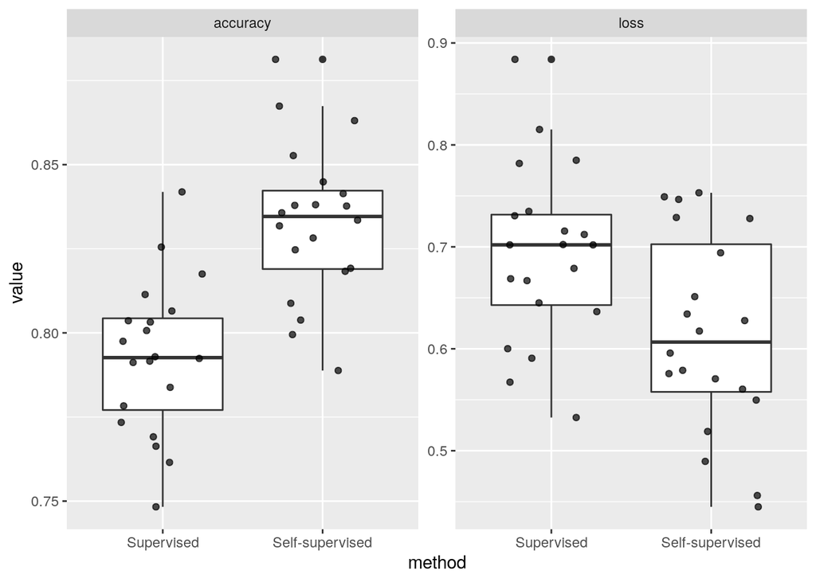

```r
## Downstream task
## ----------------------------------------------------------------------------
## CNN model for image classification
modelDown <- keras_model_sequential(name = "MNIST-CNN-Downstream") %>%
  layer_conv_2d(filters = 64, kernel_size = 2, padding = "same",
                activation = "relu", input_shape = c(28, 28, 1)) %>%
  layer_max_pooling_2d(pool_size = 2) %>%
  layer_dropout(rate = 0.3) %>%
  layer_conv_2d(filters = 32, kernel_size = 2, padding = "same",
                activation = "relu") %>%
  layer_max_pooling_2d(pool_size = 2) %>%
  layer_dropout(rate = 0.3) %>%
  layer_flatten() %>%
  layer_dense(units = 256, activation = "relu") %>%
  layer_dropout(rate = 0.5) %>%
  layer_dense(units = 10, activation = "softmax")

## take over weights from pretext task for first few layers
weights_down <- get_weights(modelDown)
weights_down[[1]] <- weights_rotation[[1]]
weights_down[[2]] <- weights_rotation[[2]]
weights_down[[3]] <- weights_rotation[[3]]
weights_down[[4]] <- weights_rotation[[4]]
weights_down[[5]] <- weights_rotation[[5]]
weights_down[[6]] <- weights_rotation[[6]]

## fit model M times with different small data sets and get test error
M <- 20
testerrSelf <- t(replicate(n = M, expr = {

  ## overwrite weights with initialization weights from pretext task
  modelDown %>%
    set_weights(weights = weights_down)

    ## freeze weights from convolution layers
  modelDown %>%
    freeze_weights(from = 1, to = 4)
  # summary(modelDown)

  ## compile model
  modelDown %>%
    compile(loss = "categorical_crossentropy",
            optimizer = "adam",
            metrics = c("accuracy"))

  ## draw a small data set
  sdat <- smallData(perc = 0.0025)

  ## calibrate parameters in last layers first ("model head")
  modelDown %>%
    fit(x = sdat$x,
        y = sdat$yBin,
        batch_size = 1,
        epochs = 10,
        validation_split = 0.2)

  ## unfreeze weights
  modelDown %>%
    unfreeze_weights()

  ## compile model again
  modelDown %>%
    compile(loss = "categorical_crossentropy",
            optimizer = "adam",
            metrics = c("accuracy"))

  ## fit the whole model including parameters from conv layers
  modelDown %>%
    fit(x = sdat$x,
        y = sdat$yBin,
        batch_size = 1,
        epochs = 10,
        validation_split = 0.2)

  ## evaluate on test data
  testErr <- modelDown %>%
  evaluate(x = mnist$test$x,
           y = mnist$test$yBin,
           verbose = 0)
  return(c(loss = testErr$loss, accuracy = testErr$accuracy))
}, simplify = TRUE))

## Plot testerror
library(ggplot2)
library(dplyr)
library(tidyr)
rbind(data.frame(testerrSuper, method = "Supervised"),
      data.frame(testerrSelf, method = "Self-supervised")) %>%
  gather(key = "variable", value = "value", accuracy, loss) %>%
  ggplot(aes(x = method , y = value)) +
  geom_boxplot() +
  geom_jitter(alpha = 0.7, width = 0.3) +
  facet_wrap(~ variable, scales = "free")
```

## Important things we learned

- Definition of pretext task is crucial
- We should probably not use classification or a different loss function for a rotation task
- First freeze transfered weights and calibrate the remaining part of the model
- Train model again a bit afterwards (but easy to overfit!)

## Discussion points

- Could self-supervised learning be used in your field?
- How could a pretext task could look like?
- In which other fields do you see applications?

## Useful links

- [List](https://github.com/jason718/awesome-self-supervised-learning) with many relevant papers from arXiv
- [Review](https://arxiv.org/pdf/1902.06162.pdf) paper of self-supervised learning in computer vision
- [Talk](https://www.youtube.com/watch?v=SaJL4SLfrcY) by Yann LeCun on self-supervised learning